# Práctico 3. Clase 4 de Análisis y Curación

Andrés Vázquez y Sergio Buzzi

# Inciso 1

- Elija un dataset clasificado de su preferencia y area (domain expertise), aplique un metodo de clustering y/o mixtura de Gaussianas en el mismo.

## Datos

Se tiene información sobre 46 variables, para los 479 barrios de la Ciudad de Córdoba, originaria de la Encuesta Provincial de hogares de la Provincia de Córdoba 2008.

```r
#load("base.RData")
# En base se tiene la información de 46 variables
#save(base, file="datosbarrios.RData")
#dim(base)
load("datosbarrios.RData")
```

```r
attach(base)
educ=base[,1:11]
leer=base[,12:13]
salud=base[,14:15]
empleo=base[,16:18]
nbi=base[,20:24]
privacion=base[,25:28]
vivienda=base[,29:33]
habitantes=base[,34:41]
std=base[,42:46]

#Para que tenga sentido el análisis se toman algunos ratios por cuestiones conceptuales,
# por ejemplo la cantidad de personas empleadas en un barrio esta influenciada por las personas en
# condición de trabajar (14 años o mas)
educstd=educ/jefes
leerstd=leer/pob3omas
saludstd=salud/poblacion
empleostd=empleo/pob14omas
nbistd=nbi/poblacion
privacionstd=privacion/poblacion
viviendastd=vivienda/hogares
habitantesstd=habitantes/hogares

basestd=cbind(educstd,leerstd,saludstd,empleostd,nbistd,privacionstd,viviendastd,habitantesstd)
sub=subset(cbind(basestd,poblacion),poblacion>=2000)
semibase=sub[,-ncol(sub)]

# se saca del listado sacar del listado: inicial, sabeleer, cobertura, ocupados, inactivos, sinprivacion, casa, uno, o sea se dejan esaca categorías como referencia
datos=semibase[,-c(1,12,14,16,18,24,28,33)]
dat=datos
```

## Aplicación de clustering

### Un alogritmo de clustering jerárquico

```r
#cluster jerárquico
hc = hclust(dist(dat), method = 'ward')
```

```
## The "ward" method has been renamed to "ward.D"; note new "ward.D2"
```

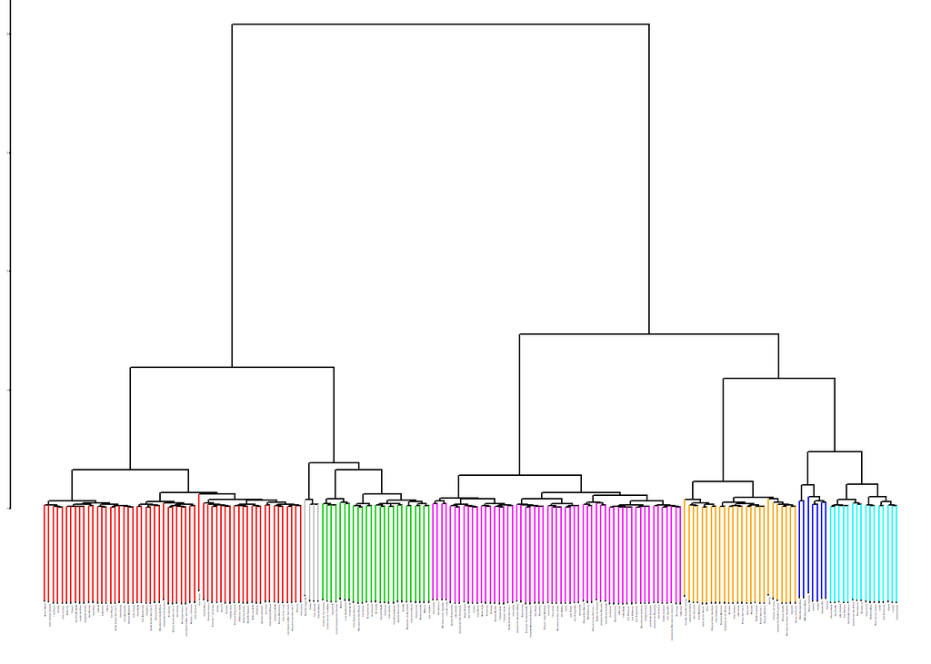

```r
par(mar=c(0,5,0,0), cex=0.08)
y=cutree(hc, 7)
library(sparcl)
ColorDendrogram(hc, y = y, labels = names(y), branchlength = 4)#plot52
```

### Clustering por kmeans con un k arbitrario (k=3)

```r
library(fpc)
fit=kmeansruns(dat,krange=3,criterion="ch")
```

En muchos casos se recomienda armar los grupos en base a los componentes principales mas importantes. Del siguiente modo se puede aplicar componentes principales:

```r
library(FactoMineR)
par(cex=0.05)
result <- PCA(dat)
```

[figure not shown]

[figure not shown]

```r
summary(result)
```

```
##
## Call:
## PCA(X = dat)
##
##
## Eigenvalues
##                        Dim.1   Dim.2   Dim.3   Dim.4   Dim.5   Dim.6
## Variance              15.226   4.051   2.582   2.150   1.137   1.015
## % of var.             47.582  12.660   8.068   6.718   3.553   3.172
## Cumulative % of var.  47.582  60.242  68.310  75.028  78.581  81.753
##                        Dim.7   Dim.8   Dim.9  Dim.10  Dim.11  Dim.12
## Variance               0.772   0.701   0.595   0.543   0.482   0.391
## % of var.              2.412   2.190   1.861   1.696   1.507   1.222
## Cumulative % of var.  84.165  86.355  88.216  89.911  91.419  92.641
##                       Dim.13  Dim.14  Dim.15  Dim.16  Dim.17  Dim.18
## Variance               0.321   0.297   0.260   0.233   0.190   0.184
## % of var.              1.002   0.927   0.811   0.729   0.593   0.576
## Cumulative % of var.  93.643  94.570  95.381  96.110  96.703  97.279
##                       Dim.19  Dim.20  Dim.21  Dim.22  Dim.23  Dim.24
## Variance               0.145   0.124   0.117   0.101   0.081   0.073
## % of var.              0.453   0.387   0.366   0.316   0.254   0.229
## Cumulative % of var.  97.731  98.118  98.484  98.800  99.054  99.283
##                       Dim.25  Dim.26  Dim.27  Dim.28  Dim.29  Dim.30
## Variance               0.052   0.046   0.038   0.037   0.029   0.018
## % of var.              0.163   0.144   0.118   0.115   0.089   0.056
## Cumulative % of var.  99.446  99.590  99.709  99.824  99.913  99.970
##                       Dim.31  Dim.32
## Variance               0.010   0.000
## % of var.              0.030   0.000
## Cumulative % of var. 100.000 100.000
##
## Individuals (the 10 first)
##                     Dist    Dim.1    ctr   cos2    Dim.2    ctr   cos2
## 1 de Mayo       |  2.487 |  1.231  0.051  0.245 | -1.427  0.259  0.329 |
## 2 de Septiembre |  9.444 |  7.960  2.145  0.710 |  0.341  0.015  0.001 |
## Acosta          |  2.957 |  1.639  0.091  0.307 | -0.754  0.072  0.065 |
## Alberdi         |  9.956 | -6.340  1.361  0.406 |  7.016  6.264  0.497 |
## Alta Córdoba    |  4.682 | -3.510  0.417  0.562 |  2.418  0.744  0.267 |
## Altamira        |  3.243 | -1.450  0.071  0.200 | -1.204  0.185  0.138 |
## Alto Alberdi    |  2.885 | -2.549  0.220  0.781 |  0.597  0.045  0.043 |
```

[output cut: 23 more lines]

```
## univinc         | -0.825  4.467  0.680 |  0.401  3.966  0.161 | -0.038
## univcomp        | -0.800  4.206  0.640 |  0.108  0.288  0.012 |  0.389
## posinc          | -0.714  3.348  0.510 |  0.268  1.780  0.072 |  0.295
## poscomp         | -0.624  2.557  0.389 |  0.057  0.081  0.003 |  0.471
##                    ctr   cos2
## priminc          0.379  0.010 |
## primcomp         1.938  0.050 |
## secinc           3.256  0.084 |
## seccomp          0.536  0.014 |
## terinc           0.070  0.002 |
## tercomp          1.965  0.051 |
## univinc          0.056  0.001 |
## univcomp         5.867  0.151 |
## posinc           3.378  0.087 |
## poscomp          8.584  0.222 |
```

[figure not shown]

```r
plot(result) # gráficos varios entre ellos el biplot
```

```r
res=result$ind$coord[]
#primeros dos componentes
x1 = res[,1]
x2 = res[,2]
```

y luego correr kmeans, sobre los primeros componentes principales, por ejemplo los dos primeros:

```r
fit=kmeansruns(cbind(x1,x2),krange=3,criterion="ch")
```

# Inciso 2

- Investigue los resultados en el meta parametro K numero de cumulos e investigue posibles procesos de seleccion del mismo.

Se puede aplicar kmeans para diversos k usando el argumento krange de la función kmeansruns, por ejemplo para $k=1,...10$. Para seleccionar k, se podría acudir alguna función de la suma de cuadrados dentro de los clusters y entre clusters. En la misma función kmeansruns estan implementados algunos criterios de selección de k (average silhouette width y Calinski-Harabasz). Por ejemplo aquí se implementa la selección del k optimo entre $k=1,...10$, por el método Calinski-Harabasz:

```r
fit = kmeansruns(dat,krange=1:10,criterion="ch")
```

# Inciso 3

- Comente la influencia de la normalización de los datos en los resultados del clustering.

```r
fit =kmeansruns(dat,krange=1:10,criterion="ch", scaledata=TRUE)
```

Al trabajar con los datos estandarizados se encuentran dos clusters. La estandarización no modificó demasiado el análisis. Esto puede deberse a que las transformaciónes previar realizadas sobre las variables generan cierto grado de estandarización.

Finalmente, se grafican los clusters y se ven cuantos barrios hay en cada uno de ellos

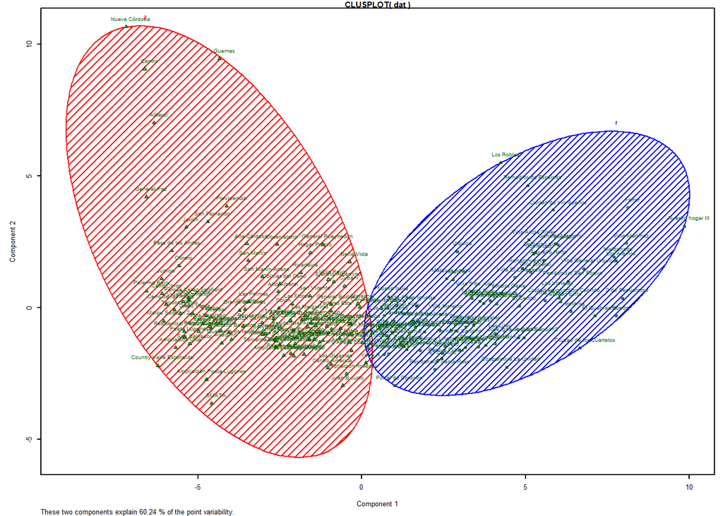

```r
library(cluster)
#fit1 <- kmeans(dat, 2, nstart=100, scale=TRUE)
par(mar=c(5,5,1,1), cex=0.4)
clusplot(dat, fit$cluster, color=TRUE, shade=TRUE,
         labels=2, lines=0, cex=0.8)
```

```r
#par(opar)
table(fit$cluster)
```

```
##
##   1   2
##  87 107
```